# Risk Factor Analysis

## Outcome Variable

**Outcome Variable:** sstunted

## Predictor Variables

**Intervention Variable:** tr

**Adjustment Set:**

unadjusted

## Stratifying Variables

The analysis was stratified on these variable(s):

- agecat
- studyid
- country
- intXparity

## Data Summary

| agecat | studyid | country | intXparity | sstunted | n_cell | n |
| --- | --- | --- | --- | --- | --- | --- |
| Birth | iLiNS_DYADM_LNS | MALAWI | 1_Birth | 0 | 0 | 1 |
| Birth | iLiNS_DYADM_LNS | MALAWI | 1_Birth | 1 | 1 | 1 |
| Birth | ki1000304b-SAS-CompFeed | INDIA | 1_Birth | 0 | 36 | 39 |
| Birth | ki1000304b-SAS-CompFeed | INDIA | 1_Birth | 1 | 3 | 39 |
| Birth | ki1000304b-SAS-CompFeed | INDIA | 2_Birth | 0 | 36 | 42 |
| Birth | ki1000304b-SAS-CompFeed | INDIA | 2_Birth | 1 | 6 | 42 |
| Birth | ki1000304b-SAS-CompFeed | INDIA | 3+_Birth | 0 | 61 | 63 |
| Birth | ki1000304b-SAS-CompFeed | INDIA | 3+_Birth | 1 | 2 | 63 |
| Birth | ki1126311-ZVITAMBO | ZIMBABWE | 1_Birth | 0 | 5777 | 5972 |
| Birth | ki1126311-ZVITAMBO | ZIMBABWE | 1_Birth | 1 | 195 | 5972 |
| Birth | ki1126311-ZVITAMBO | ZIMBABWE | 2_Birth | 0 | 4022 | 4125 |
| Birth | ki1126311-ZVITAMBO | ZIMBABWE | 2_Birth | 1 | 103 | 4125 |
| Birth | ki1126311-ZVITAMBO | ZIMBABWE | 3+_Birth | 0 | 3589 | 3732 |
| Birth | ki1126311-ZVITAMBO | ZIMBABWE | 3+_Birth | 1 | 143 | 3732 |
| Birth | ki1135781-COHORTS | GUATEMALA | 1_Birth | 0 | 109 | 112 |
| Birth | ki1135781-COHORTS | GUATEMALA | 1_Birth | 1 | 3 | 112 |
| Birth | ki1135781-COHORTS | GUATEMALA | 2_Birth | 0 | 134 | 137 |
| Birth | ki1135781-COHORTS | GUATEMALA | 2_Birth | 1 | 3 | 137 |
| Birth | ki1135781-COHORTS | GUATEMALA | 3+_Birth | 0 | 598 | 603 |
| Birth | ki1135781-COHORTS | GUATEMALA | 3+_Birth | 1 | 5 | 603 |
| Birth | ki1148112-iLiNS-DYAD-M | MALAWI | 1_Birth | 0 | 0 | 1 |
| Birth | ki1148112-iLiNS-DYAD-M | MALAWI | 1_Birth | 1 | 1 | 1 |
| Birth | kiGH5241-JiVitA-3 | BANGLADESH | 1_Birth | 0 | 10744 | 12542 |
| Birth | kiGH5241-JiVitA-3 | BANGLADESH | 1_Birth | 1 | 1798 | 12542 |
| Birth | kiGH5241-JiVitA-3 | BANGLADESH | 2_Birth | 0 | 12254 | 13420 |
| Birth | kiGH5241-JiVitA-3 | BANGLADESH | 2_Birth | 1 | 1166 | 13420 |
| Birth | kiGH5241-JiVitA-3 | BANGLADESH | 3+_Birth | 0 | 12110 | 13226 |
| Birth | kiGH5241-JiVitA-3 | BANGLADESH | 3+_Birth | 1 | 1116 | 13226 |
| 6 months | iLiNS_DYADM_LNS | MALAWI | 1_6 months | 0 | 116 | 122 |
| 6 months | iLiNS_DYADM_LNS | MALAWI | 1_6 months | 1 | 6 | 122 |

[output cut: 114 more lines]

The following strata were considered:

- agecat: 24 months, studyid: iLiNS_DYADM_LNS, country: MALAWI, intXparity: 1_24 months
- agecat: 24 months, studyid: iLiNS_DYADM_LNS, country: MALAWI, intXparity: 2_24 months
- agecat: 24 months, studyid: iLiNS_DYADM_LNS, country: MALAWI, intXparity: 3+_24 months
- agecat: 24 months, studyid: ki1000110-WASH-Bangladesh, country: BANGLADESH, intXparity: 1_24 months
- agecat: 24 months, studyid: ki1000110-WASH-Bangladesh, country: BANGLADESH, intXparity: 2_24 months
- agecat: 24 months, studyid: ki1000110-WASH-Bangladesh, country: BANGLADESH, intXparity: 3+_24 months
- agecat: 24 months, studyid: ki1017093b-PROVIDE, country: BANGLADESH, intXparity: 1_24 months
- agecat: 24 months, studyid: ki1017093b-PROVIDE, country: BANGLADESH, intXparity: 2_24 months
- agecat: 24 months, studyid: ki1066203-TanzaniaChild2, country: TANZANIA, UNITED REPUBLIC OF, intXparity: 1_24 months
- agecat: 24 months, studyid: ki1066203-TanzaniaChild2, country: TANZANIA, UNITED REPUBLIC OF, intXparity: 3+_24 months
- agecat: 24 months, studyid: ki1112895-Burkina Faso Zn, country: BURKINA FASO, intXparity: 1_24 months
- agecat: 24 months, studyid: ki1112895-Burkina Faso Zn, country: BURKINA FASO, intXparity: 2_24 months
- agecat: 24 months, studyid: ki1112895-Burkina Faso Zn, country: BURKINA FASO, intXparity: 3+_24 months
- agecat: 24 months, studyid: ki1126311-ZVITAMBO, country: ZIMBABWE, intXparity: 1_24 months
- agecat: 24 months, studyid: ki1126311-ZVITAMBO, country: ZIMBABWE, intXparity: 2_24 months
- agecat: 24 months, studyid: ki1126311-ZVITAMBO, country: ZIMBABWE, intXparity: 3+_24 months
- agecat: 24 months, studyid: ki1135781-COHORTS, country: GUATEMALA, intXparity: 1_24 months
- agecat: 24 months, studyid: ki1135781-COHORTS, country: GUATEMALA, intXparity: 2_24 months
- agecat: 24 months, studyid: ki1135781-COHORTS, country: GUATEMALA, intXparity: 3+_24 months
- agecat: 24 months, studyid: ki1148112-iLiNS-DYAD-M, country: MALAWI, intXparity: 1_24 months
- agecat: 24 months, studyid: ki1148112-iLiNS-DYAD-M, country: MALAWI, intXparity: 2_24 months
- agecat: 24 months, studyid: ki1148112-iLiNS-DYAD-M, country: MALAWI, intXparity: 3+_24 months
- agecat: 24 months, studyid: kiGH5241-JiVitA-3, country: BANGLADESH, intXparity: 1_24 months
- agecat: 24 months, studyid: kiGH5241-JiVitA-3, country: BANGLADESH, intXparity: 2_24 months
- agecat: 24 months, studyid: kiGH5241-JiVitA-3, country: BANGLADESH, intXparity: 3+_24 months
- agecat: 6 months, studyid: iLiNS_DYADM_LNS, country: MALAWI, intXparity: 1_6 months
- agecat: 6 months, studyid: iLiNS_DYADM_LNS, country: MALAWI, intXparity: 2_6 months
- agecat: 6 months, studyid: iLiNS_DYADM_LNS, country: MALAWI, intXparity: 3+_6 months
- agecat: 6 months, studyid: ki1000110-WASH-Bangladesh, country: BANGLADESH, intXparity: 1_6 months
- agecat: 6 months, studyid: ki1000110-WASH-Bangladesh, country: BANGLADESH, intXparity: 2_6 months
- agecat: 6 months, studyid: ki1000110-WASH-Bangladesh, country: BANGLADESH, intXparity: 3+_6 months
- agecat: 6 months, studyid: ki1000304b-SAS-CompFeed, country: INDIA, intXparity: 1_6 months
- agecat: 6 months, studyid: ki1000304b-SAS-CompFeed, country: INDIA, intXparity: 2_6 months
- agecat: 6 months, studyid: ki1000304b-SAS-CompFeed, country: INDIA, intXparity: 3+_6 months
- agecat: 6 months, studyid: ki1000304b-SAS-FoodSuppl, country: INDIA, intXparity: 1_6 months
- agecat: 6 months, studyid: ki1000304b-SAS-FoodSuppl, country: INDIA, intXparity: 2_6 months
- agecat: 6 months, studyid: ki1000304b-SAS-FoodSuppl, country: INDIA, intXparity: 3+_6 months
- agecat: 6 months, studyid: ki1017093b-PROVIDE, country: BANGLADESH, intXparity: 1_6 months
- agecat: 6 months, studyid: ki1017093b-PROVIDE, country: BANGLADESH, intXparity: 2_6 months
- agecat: 6 months, studyid: ki1017093b-PROVIDE, country: BANGLADESH, intXparity: 3+_6 months
- agecat: 6 months, studyid: ki1066203-TanzaniaChild2, country: TANZANIA, UNITED REPUBLIC OF, intXparity: 1_6 months
- agecat: 6 months, studyid: ki1066203-TanzaniaChild2, country: TANZANIA, UNITED REPUBLIC OF, intXparity: 2_6 months
- agecat: 6 months, studyid: ki1066203-TanzaniaChild2, country: TANZANIA, UNITED REPUBLIC OF, intXparity: 3+_6 months
- agecat: 6 months, studyid: ki1112895-Burkina Faso Zn, country: BURKINA FASO, intXparity: 1_6 months
- agecat: 6 months, studyid: ki1112895-Burkina Faso Zn, country: BURKINA FASO, intXparity: 2_6 months
- agecat: 6 months, studyid: ki1112895-Burkina Faso Zn, country: BURKINA FASO, intXparity: 3+_6 months
- agecat: 6 months, studyid: ki1126311-ZVITAMBO, country: ZIMBABWE, intXparity: 1_6 months
- agecat: 6 months, studyid: ki1126311-ZVITAMBO, country: ZIMBABWE, intXparity: 2_6 months
- agecat: 6 months, studyid: ki1126311-ZVITAMBO, country: ZIMBABWE, intXparity: 3+_6 months
- agecat: 6 months, studyid: ki1135781-COHORTS, country: GUATEMALA, intXparity: 1_6 months
- agecat: 6 months, studyid: ki1135781-COHORTS, country: GUATEMALA, intXparity: 2_6 months
- agecat: 6 months, studyid: ki1135781-COHORTS, country: GUATEMALA, intXparity: 3+_6 months
- agecat: 6 months, studyid: ki1148112-iLiNS-DYAD-M, country: MALAWI, intXparity: 1_6 months
- agecat: 6 months, studyid: ki1148112-iLiNS-DYAD-M, country: MALAWI, intXparity: 2_6 months
- agecat: 6 months, studyid: ki1148112-iLiNS-DYAD-M, country: MALAWI, intXparity: 3+_6 months
- agecat: 6 months, studyid: kiGH5241-JiVitA-3, country: BANGLADESH, intXparity: 1_6 months
- agecat: 6 months, studyid: kiGH5241-JiVitA-3, country: BANGLADESH, intXparity: 2_6 months
- agecat: 6 months, studyid: kiGH5241-JiVitA-3, country: BANGLADESH, intXparity: 3+_6 months
- agecat: Birth, studyid: iLiNS_DYADM_LNS, country: MALAWI, intXparity: 1_Birth
- agecat: Birth, studyid: ki1000304b-SAS-CompFeed, country: INDIA, intXparity: 1_Birth
- agecat: Birth, studyid: ki1000304b-SAS-CompFeed, country: INDIA, intXparity: 2_Birth
- agecat: Birth, studyid: ki1000304b-SAS-CompFeed, country: INDIA, intXparity: 3+_Birth
- agecat: Birth, studyid: ki1126311-ZVITAMBO, country: ZIMBABWE, intXparity: 1_Birth
- agecat: Birth, studyid: ki1126311-ZVITAMBO, country: ZIMBABWE, intXparity: 2_Birth
- agecat: Birth, studyid: ki1126311-ZVITAMBO, country: ZIMBABWE, intXparity: 3+_Birth
- agecat: Birth, studyid: ki1135781-COHORTS, country: GUATEMALA, intXparity: 1_Birth
- agecat: Birth, studyid: ki1135781-COHORTS, country: GUATEMALA, intXparity: 2_Birth
- agecat: Birth, studyid: ki1135781-COHORTS, country: GUATEMALA, intXparity: 3+_Birth
- agecat: Birth, studyid: ki1148112-iLiNS-DYAD-M, country: MALAWI, intXparity: 1_Birth
- agecat: Birth, studyid: kiGH5241-JiVitA-3, country: BANGLADESH, intXparity: 1_Birth
- agecat: Birth, studyid: kiGH5241-JiVitA-3, country: BANGLADESH, intXparity: 2_Birth
- agecat: Birth, studyid: kiGH5241-JiVitA-3, country: BANGLADESH, intXparity: 3+_Birth

### Dropped Strata

Some strata were dropped due to rare outcomes:

- agecat: Birth, studyid: iLiNS_DYADM_LNS, country: MALAWI, intXparity: 1_Birth
- agecat: Birth, studyid: ki1000304b-SAS-CompFeed, country: INDIA, intXparity: 1_Birth
- agecat: Birth, studyid: ki1000304b-SAS-CompFeed, country: INDIA, intXparity: 3+_Birth
- agecat: Birth, studyid: ki1135781-COHORTS, country: GUATEMALA, intXparity: 1_Birth
- agecat: Birth, studyid: ki1135781-COHORTS, country: GUATEMALA, intXparity: 2_Birth
- agecat: Birth, studyid: ki1148112-iLiNS-DYAD-M, country: MALAWI, intXparity: 1_Birth
- agecat: 6 months, studyid: ki1017093b-PROVIDE, country: BANGLADESH, intXparity: 1_6 months
- agecat: 6 months, studyid: ki1017093b-PROVIDE, country: BANGLADESH, intXparity: 2_6 months
- agecat: 6 months, studyid: ki1017093b-PROVIDE, country: BANGLADESH, intXparity: 3+_6 months
- agecat: 6 months, studyid: ki1112895-Burkina Faso Zn, country: BURKINA FASO, intXparity: 2_6 months
- agecat: 24 months, studyid: iLiNS_DYADM_LNS, country: MALAWI, intXparity: 1_24 months
- agecat: 24 months, studyid: iLiNS_DYADM_LNS, country: MALAWI, intXparity: 2_24 months
- agecat: 24 months, studyid: iLiNS_DYADM_LNS, country: MALAWI, intXparity: 3+_24 months
- agecat: 24 months, studyid: ki1017093b-PROVIDE, country: BANGLADESH, intXparity: 1_24 months
- agecat: 24 months, studyid: ki1017093b-PROVIDE, country: BANGLADESH, intXparity: 2_24 months
- agecat: 24 months, studyid: ki1066203-TanzaniaChild2, country: TANZANIA, UNITED REPUBLIC OF, intXparity: 1_24 months
- agecat: 24 months, studyid: ki1066203-TanzaniaChild2, country: TANZANIA, UNITED REPUBLIC OF, intXparity: 3+_24 months
- agecat: 24 months, studyid: ki1126311-ZVITAMBO, country: ZIMBABWE, intXparity: 2_24 months
- agecat: 24 months, studyid: ki1148112-iLiNS-DYAD-M, country: MALAWI, intXparity: 1_24 months
- agecat: 24 months, studyid: ki1148112-iLiNS-DYAD-M, country: MALAWI, intXparity: 2_24 months
- agecat: 24 months, studyid: kiGH5241-JiVitA-3, country: BANGLADESH, intXparity: 3+_24 months

## Methods Detail

We’re interested in the causal parameters $E[Y_a]$ for all values of $a \in \mathcal{A}$. These parameters represent the mean outcome if, possibly contrary to fact, we intervened to set all units to have $A=a$. Under the randomization and positivity assumptions, these are identified by the statistical parameters $\psi_a=E_W[E_{Y|A,W}(Y|A=a,W)]$. In addition, we’re interested in the mean of $Y$, $E[Y]$ under no intervention (the observed mean). We will estimate these parameters by using SuperLearner to fit the relevant likelihood factors – $E_{Y|A,W}(Y|A=a,W)$ and $p(A=a|W)$, and then updating our likelihood fit using a joint TMLE.

For unadjusted analyses ($W=\{\}$), initial likelihoods were estimated using Lrnr_glm to estimate the simple $E(Y|A)$ and Lrnr_mean to estimate $p(A)$. For adjusted analyses, a small library containing Lrnr_glmnet, Lrnr_xgboost, and Lrnr_mean was used.

Having estimated these parameters, we will then use the delta method to estimate relative risks and attributable risks relative to a prespecified baseline level of $A$.

[output not shown]

# Results Detail

## Results Plots

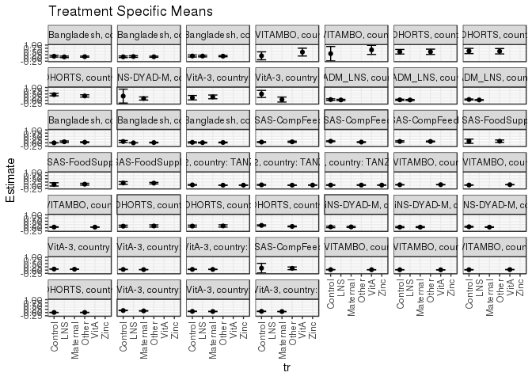

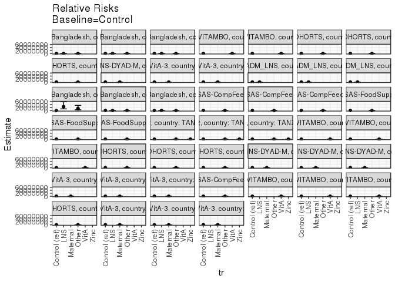

[figure not shown]

[figure not shown]

## Results Table

### Parameter: TSM

| agecat | studyid | country | intXparity | intervention_level | baseline_level | estimate | ci_lower | ci_upper |
| --- | --- | --- | --- | --- | --- | --- | --- | --- |
| Birth | ki1000304b-SAS-CompFeed | INDIA | 2_Birth | Control | NA | 0.1538462 | -0.2183146 | 0.5260069 |
| Birth | ki1000304b-SAS-CompFeed | INDIA | 2_Birth | Other | NA | 0.1379310 | 0.0336746 | 0.2421874 |
| Birth | ki1126311-ZVITAMBO | ZIMBABWE | 1_Birth | Control | NA | 0.0360544 | 0.0265236 | 0.0455853 |
| Birth | ki1126311-ZVITAMBO | ZIMBABWE | 1_Birth | VitA | NA | 0.0315415 | 0.0264357 | 0.0366473 |
| Birth | ki1126311-ZVITAMBO | ZIMBABWE | 2_Birth | Control | NA | 0.0287413 | 0.0184309 | 0.0390517 |
| Birth | ki1126311-ZVITAMBO | ZIMBABWE | 2_Birth | VitA | NA | 0.0237484 | 0.0184015 | 0.0290953 |
| Birth | ki1126311-ZVITAMBO | ZIMBABWE | 3+_Birth | Control | NA | 0.0309278 | 0.0200317 | 0.0418240 |
| Birth | ki1126311-ZVITAMBO | ZIMBABWE | 3+_Birth | VitA | NA | 0.0409124 | 0.0335240 | 0.0483008 |
| Birth | ki1135781-COHORTS | GUATEMALA | 3+_Birth | Control | NA | 0.0071429 | -0.0027292 | 0.0170149 |
| Birth | ki1135781-COHORTS | GUATEMALA | 3+_Birth | Other | NA | 0.0092879 | -0.0011819 | 0.0197578 |
| Birth | kiGH5241-JiVitA-3 | BANGLADESH | 1_Birth | Control | NA | 0.1578444 | 0.1447426 | 0.1709462 |
| Birth | kiGH5241-JiVitA-3 | BANGLADESH | 1_Birth | Maternal | NA | 0.1288676 | 0.1148747 | 0.1428605 |
| Birth | kiGH5241-JiVitA-3 | BANGLADESH | 2_Birth | Control | NA | 0.0913160 | 0.0799320 | 0.1027000 |
| Birth | kiGH5241-JiVitA-3 | BANGLADESH | 2_Birth | Maternal | NA | 0.0824650 | 0.0721843 | 0.0927458 |
| Birth | kiGH5241-JiVitA-3 | BANGLADESH | 3+_Birth | Control | NA | 0.0908531 | 0.0783211 | 0.1033851 |
| Birth | kiGH5241-JiVitA-3 | BANGLADESH | 3+_Birth | Maternal | NA | 0.0781343 | 0.0685568 | 0.0877118 |
| 6 months | iLiNS_DYADM_LNS | MALAWI | 1_6 months | Control | NA | 0.0625000 | 0.0029515 | 0.1220485 |
| 6 months | iLiNS_DYADM_LNS | MALAWI | 1_6 months | LNS | NA | 0.0344828 | -0.0126695 | 0.0816350 |
| 6 months | iLiNS_DYADM_LNS | MALAWI | 2_6 months | Control | NA | 0.0454545 | 0.0017902 | 0.0891189 |
| 6 months | iLiNS_DYADM_LNS | MALAWI | 2_6 months | LNS | NA | 0.0312500 | -0.0115183 | 0.0740183 |
| 6 months | iLiNS_DYADM_LNS | MALAWI | 3+_6 months | Control | NA | 0.0707071 | 0.0349587 | 0.1064554 |
| 6 months | iLiNS_DYADM_LNS | MALAWI | 3+_6 months | LNS | NA | 0.0333333 | 0.0090253 | 0.0576413 |
| 6 months | ki1000110-WASH-Bangladesh | BANGLADESH | 1_6 months | Control | NA | 0.0000000 | 0.0000000 | 0.0000000 |
| 6 months | ki1000110-WASH-Bangladesh | BANGLADESH | 1_6 months | LNS | NA | 0.0833333 | 0.0193541 | 0.1473126 |
| 6 months | ki1000110-WASH-Bangladesh | BANGLADESH | 1_6 months | Other | NA | 0.0454545 | 0.0064441 | 0.0844650 |
| 6 months | ki1000110-WASH-Bangladesh | BANGLADESH | 2_6 months | Control | NA | 0.1000000 | 0.0166317 | 0.1833683 |
| 6 months | ki1000110-WASH-Bangladesh | BANGLADESH | 2_6 months | LNS | NA | 0.0000000 | 0.0000000 | 0.0000000 |
| 6 months | ki1000110-WASH-Bangladesh | BANGLADESH | 2_6 months | Other | NA | 0.0206186 | -0.0077334 | 0.0489706 |
| 6 months | ki1000110-WASH-Bangladesh | BANGLADESH | 3+_6 months | Control | NA | 0.0363636 | -0.0132174 | 0.0859447 |
| 6 months | ki1000110-WASH-Bangladesh | BANGLADESH | 3+_6 months | LNS | NA | 0.0163934 | -0.0155431 | 0.0483300 |

[output cut: 71 more lines]

### Parameter: E(Y)

| agecat | studyid | country | intXparity | intervention_level | baseline_level | estimate | ci_lower | ci_upper |
| --- | --- | --- | --- | --- | --- | --- | --- | --- |
| Birth | ki1000304b-SAS-CompFeed | INDIA | 2_Birth | NA | NA | 0.1428571 | 0.0046946 | 0.2810197 |
| Birth | ki1126311-ZVITAMBO | ZIMBABWE | 1_Birth | NA | NA | 0.0326524 | 0.0281445 | 0.0371603 |
| Birth | ki1126311-ZVITAMBO | ZIMBABWE | 2_Birth | NA | NA | 0.0249697 | 0.0202075 | 0.0297319 |
| Birth | ki1126311-ZVITAMBO | ZIMBABWE | 3+_Birth | NA | NA | 0.0383173 | 0.0321577 | 0.0444768 |
| Birth | ki1135781-COHORTS | GUATEMALA | 3+_Birth | NA | NA | 0.0082919 | 0.0010480 | 0.0155357 |
| Birth | kiGH5241-JiVitA-3 | BANGLADESH | 1_Birth | NA | NA | 0.1433583 | 0.1337069 | 0.1530098 |
| Birth | kiGH5241-JiVitA-3 | BANGLADESH | 2_Birth | NA | NA | 0.0868852 | 0.0792013 | 0.0945692 |
| Birth | kiGH5241-JiVitA-3 | BANGLADESH | 3+_Birth | NA | NA | 0.0843793 | 0.0765100 | 0.0922485 |
| 6 months | iLiNS_DYADM_LNS | MALAWI | 1_6 months | NA | NA | 0.0491803 | 0.0106502 | 0.0877104 |
| 6 months | iLiNS_DYADM_LNS | MALAWI | 2_6 months | NA | NA | 0.0394737 | 0.0084161 | 0.0705313 |
| 6 months | iLiNS_DYADM_LNS | MALAWI | 3+_6 months | NA | NA | 0.0514706 | 0.0300044 | 0.0729368 |
| 6 months | ki1000110-WASH-Bangladesh | BANGLADESH | 1_6 months | NA | NA | 0.0476190 | 0.0200971 | 0.0751410 |
| 6 months | ki1000110-WASH-Bangladesh | BANGLADESH | 2_6 months | NA | NA | 0.0358974 | 0.0097192 | 0.0620757 |
| 6 months | ki1000110-WASH-Bangladesh | BANGLADESH | 3+_6 months | NA | NA | 0.0264317 | 0.0055176 | 0.0473458 |
| 6 months | ki1000304b-SAS-CompFeed | INDIA | 1_6 months | NA | NA | 0.0666667 | 0.0333561 | 0.0999773 |
| 6 months | ki1000304b-SAS-CompFeed | INDIA | 2_6 months | NA | NA | 0.0849673 | 0.0514083 | 0.1185264 |
| 6 months | ki1000304b-SAS-CompFeed | INDIA | 3+_6 months | NA | NA | 0.1056338 | 0.0756261 | 0.1356415 |
| 6 months | ki1000304b-SAS-FoodSuppl | INDIA | 1_6 months | NA | NA | 0.1250000 | 0.0433348 | 0.2066652 |
| 6 months | ki1000304b-SAS-FoodSuppl | INDIA | 2_6 months | NA | NA | 0.0789474 | 0.0179195 | 0.1399753 |
| 6 months | ki1000304b-SAS-FoodSuppl | INDIA | 3+_6 months | NA | NA | 0.1682692 | 0.1173060 | 0.2192324 |
| 6 months | ki1066203-TanzaniaChild2 | TANZANIA, UNITED REPUBLIC OF | 1_6 months | NA | NA | 0.0124113 | 0.0032662 | 0.0215565 |
| 6 months | ki1066203-TanzaniaChild2 | TANZANIA, UNITED REPUBLIC OF | 2_6 months | NA | NA | 0.0164835 | 0.0057938 | 0.0271732 |
| 6 months | ki1066203-TanzaniaChild2 | TANZANIA, UNITED REPUBLIC OF | 3+_6 months | NA | NA | 0.0140351 | 0.0043695 | 0.0237007 |
| 6 months | ki1126311-ZVITAMBO | ZIMBABWE | 1_6 months | NA | NA | 0.0442649 | 0.0370175 | 0.0515124 |
| 6 months | ki1126311-ZVITAMBO | ZIMBABWE | 2_6 months | NA | NA | 0.0377599 | 0.0300629 | 0.0454568 |
| 6 months | ki1126311-ZVITAMBO | ZIMBABWE | 3+_6 months | NA | NA | 0.0452002 | 0.0367504 | 0.0536499 |
| 6 months | ki1135781-COHORTS | GUATEMALA | 1_6 months | NA | NA | 0.1230769 | 0.0663849 | 0.1797690 |
| 6 months | ki1135781-COHORTS | GUATEMALA | 2_6 months | NA | NA | 0.1287879 | 0.0714275 | 0.1861482 |
| 6 months | ki1135781-COHORTS | GUATEMALA | 3+_6 months | NA | NA | 0.1343284 | 0.1084882 | 0.1601685 |
| 6 months | ki1148112-iLiNS-DYAD-M | MALAWI | 1_6 months | NA | NA | 0.0614525 | 0.0261719 | 0.0967331 |
| 6 months | ki1148112-iLiNS-DYAD-M | MALAWI | 2_6 months | NA | NA | 0.0454545 | 0.0178670 | 0.0730421 |
| 6 months | ki1148112-iLiNS-DYAD-M | MALAWI | 3+_6 months | NA | NA | 0.0510367 | 0.0337971 | 0.0682763 |
| 6 months | kiGH5241-JiVitA-3 | BANGLADESH | 1_6 months | NA | NA | 0.0761169 | 0.0688597 | 0.0833742 |
| 6 months | kiGH5241-JiVitA-3 | BANGLADESH | 2_6 months | NA | NA | 0.0464462 | 0.0406525 | 0.0522398 |
| 6 months | kiGH5241-JiVitA-3 | BANGLADESH | 3+_6 months | NA | NA | 0.0568665 | 0.0492923 | 0.0644407 |
| 24 months | ki1000110-WASH-Bangladesh | BANGLADESH | 1_24 months | NA | NA | 0.1070560 | 0.0771282 | 0.1369837 |
| 24 months | ki1000110-WASH-Bangladesh | BANGLADESH | 2_24 months | NA | NA | 0.0984043 | 0.0682572 | 0.1285513 |
| 24 months | ki1000110-WASH-Bangladesh | BANGLADESH | 3+_24 months | NA | NA | 0.1450000 | 0.1104515 | 0.1795485 |
| 24 months | ki1126311-ZVITAMBO | ZIMBABWE | 1_24 months | NA | NA | 0.3529412 | 0.1187820 | 0.5871003 |
| 24 months | ki1126311-ZVITAMBO | ZIMBABWE | 3+_24 months | NA | NA | 0.5454545 | 0.2368403 | 0.8540688 |
| 24 months | ki1135781-COHORTS | GUATEMALA | 1_24 months | NA | NA | 0.4814815 | 0.3469630 | 0.6160000 |
| 24 months | ki1135781-COHORTS | GUATEMALA | 2_24 months | NA | NA | 0.5319149 | 0.3877191 | 0.6761107 |
| 24 months | ki1135781-COHORTS | GUATEMALA | 3+_24 months | NA | NA | 0.3947368 | 0.3311509 | 0.4583228 |
| 24 months | ki1148112-iLiNS-DYAD-M | MALAWI | 3+_24 months | NA | NA | 0.1621622 | 0.0417552 | 0.2825691 |
| 24 months | kiGH5241-JiVitA-3 | BANGLADESH | 1_24 months | NA | NA | 0.2450980 | 0.1346081 | 0.3555880 |
| 24 months | kiGH5241-JiVitA-3 | BANGLADESH | 2_24 months | NA | NA | 0.3142857 | 0.1307972 | 0.4977743 |

### Parameter: RR

| agecat | studyid | country | intXparity | intervention_level | baseline_level | estimate | ci_lower | ci_upper |
| --- | --- | --- | --- | --- | --- | --- | --- | --- |
| Birth | ki1000304b-SAS-CompFeed | INDIA | 2_Birth | Control | Control | 1.0000000 | 1.0000000 | 1.0000000 |
| Birth | ki1000304b-SAS-CompFeed | INDIA | 2_Birth | Other | Control | 0.8965517 | 0.0719869 | 11.1659969 |
| Birth | ki1126311-ZVITAMBO | ZIMBABWE | 1_Birth | Control | Control | 1.0000000 | 1.0000000 | 1.0000000 |
| Birth | ki1126311-ZVITAMBO | ZIMBABWE | 1_Birth | VitA | Control | 0.8748313 | 0.6416605 | 1.1927332 |
| Birth | ki1126311-ZVITAMBO | ZIMBABWE | 2_Birth | Control | Control | 1.0000000 | 1.0000000 | 1.0000000 |
| Birth | ki1126311-ZVITAMBO | ZIMBABWE | 2_Birth | VitA | Control | 0.8262804 | 0.5409909 | 1.2620163 |
| Birth | ki1126311-ZVITAMBO | ZIMBABWE | 3+_Birth | Control | Control | 1.0000000 | 1.0000000 | 1.0000000 |
| Birth | ki1126311-ZVITAMBO | ZIMBABWE | 3+_Birth | VitA | Control | 1.3228337 | 0.8903673 | 1.9653563 |
| Birth | ki1135781-COHORTS | GUATEMALA | 3+_Birth | Control | Control | 1.0000000 | 1.0000000 | 1.0000000 |
| Birth | ki1135781-COHORTS | GUATEMALA | 3+_Birth | Other | Control | 1.3003096 | 0.2185153 | 7.7376964 |
| Birth | kiGH5241-JiVitA-3 | BANGLADESH | 1_Birth | Control | Control | 1.0000000 | 1.0000000 | 1.0000000 |
| Birth | kiGH5241-JiVitA-3 | BANGLADESH | 1_Birth | Maternal | Control | 0.8164220 | 0.7121112 | 0.9360122 |
| Birth | kiGH5241-JiVitA-3 | BANGLADESH | 2_Birth | Control | Control | 1.0000000 | 1.0000000 | 1.0000000 |
| Birth | kiGH5241-JiVitA-3 | BANGLADESH | 2_Birth | Maternal | Control | 0.9030728 | 0.7571056 | 1.0771820 |
| Birth | kiGH5241-JiVitA-3 | BANGLADESH | 3+_Birth | Control | Control | 1.0000000 | 1.0000000 | 1.0000000 |
| Birth | kiGH5241-JiVitA-3 | BANGLADESH | 3+_Birth | Maternal | Control | 0.8600068 | 0.7150862 | 1.0342974 |
| 6 months | iLiNS_DYADM_LNS | MALAWI | 1_6 months | Control | Control | 1.0000000 | 1.0000000 | 1.0000000 |
| 6 months | iLiNS_DYADM_LNS | MALAWI | 1_6 months | LNS | Control | 0.5517241 | 0.1042126 | 2.9209479 |
| 6 months | iLiNS_DYADM_LNS | MALAWI | 2_6 months | Control | Control | 1.0000000 | 1.0000000 | 1.0000000 |
| 6 months | iLiNS_DYADM_LNS | MALAWI | 2_6 months | LNS | Control | 0.6875000 | 0.1291525 | 3.6596763 |
| 6 months | iLiNS_DYADM_LNS | MALAWI | 3+_6 months | Control | Control | 1.0000000 | 1.0000000 | 1.0000000 |
| 6 months | iLiNS_DYADM_LNS | MALAWI | 3+_6 months | LNS | Control | 0.4714286 | 0.1941068 | 1.1449617 |
| 6 months | ki1000110-WASH-Bangladesh | BANGLADESH | 1_6 months | Control | Control | 1.0000000 | 1.0000000 | 1.0000000 |
| 6 months | ki1000110-WASH-Bangladesh | BANGLADESH | 1_6 months | LNS | Control | 26197168.0161835 | 11687383.5174304 | 58720723.1665344 |
| 6 months | ki1000110-WASH-Bangladesh | BANGLADESH | 1_6 months | Other | Control | 14289364.3724637 | 5846684.0307063 | 34923374.1889709 |
| 6 months | ki1000110-WASH-Bangladesh | BANGLADESH | 2_6 months | Control | Control | 1.0000000 | 1.0000000 | 1.0000000 |
| 6 months | ki1000110-WASH-Bangladesh | BANGLADESH | 2_6 months | LNS | Control | 0.0000000 | 0.0000000 | 0.0000000 |
| 6 months | ki1000110-WASH-Bangladesh | BANGLADESH | 2_6 months | Other | Control | 0.2061856 | 0.0412941 | 1.0295061 |
| 6 months | ki1000110-WASH-Bangladesh | BANGLADESH | 3+_6 months | Control | Control | 1.0000000 | 1.0000000 | 1.0000000 |
| 6 months | ki1000110-WASH-Bangladesh | BANGLADESH | 3+_6 months | LNS | Control | 0.4508197 | 0.0418125 | 4.8607102 |

[output cut: 71 more lines]

### Parameter: PAR

| agecat | studyid | country | intXparity | intervention_level | baseline_level | estimate | ci_lower | ci_upper |
| --- | --- | --- | --- | --- | --- | --- | --- | --- |
| Birth | ki1000304b-SAS-CompFeed | INDIA | 2_Birth | Control | NA | -0.0109890 | -0.2758877 | 0.2539097 |
| Birth | ki1126311-ZVITAMBO | ZIMBABWE | 1_Birth | Control | NA | -0.0034020 | -0.0115531 | 0.0047490 |
| Birth | ki1126311-ZVITAMBO | ZIMBABWE | 2_Birth | Control | NA | -0.0037716 | -0.0125453 | 0.0050020 |
| Birth | ki1126311-ZVITAMBO | ZIMBABWE | 3+_Birth | Control | NA | 0.0073894 | -0.0023548 | 0.0171336 |
| Birth | ki1135781-COHORTS | GUATEMALA | 3+_Birth | Control | NA | 0.0011490 | -0.0065596 | 0.0088576 |
| Birth | kiGH5241-JiVitA-3 | BANGLADESH | 1_Birth | Control | NA | -0.0144861 | -0.0241709 | -0.0048012 |
| Birth | kiGH5241-JiVitA-3 | BANGLADESH | 2_Birth | Control | NA | -0.0044308 | -0.0121119 | 0.0032504 |
| Birth | kiGH5241-JiVitA-3 | BANGLADESH | 3+_Birth | Control | NA | -0.0064738 | -0.0145127 | 0.0015650 |
| 6 months | iLiNS_DYADM_LNS | MALAWI | 1_6 months | Control | NA | -0.0133197 | -0.0495160 | 0.0228767 |
| 6 months | iLiNS_DYADM_LNS | MALAWI | 2_6 months | Control | NA | -0.0059809 | -0.0317401 | 0.0197784 |
| 6 months | iLiNS_DYADM_LNS | MALAWI | 3+_6 months | Control | NA | -0.0192365 | -0.0415610 | 0.0030881 |
| 6 months | ki1000110-WASH-Bangladesh | BANGLADESH | 1_6 months | Control | NA | 0.0476190 | 0.0200971 | 0.0751410 |
| 6 months | ki1000110-WASH-Bangladesh | BANGLADESH | 2_6 months | Control | NA | -0.0641026 | -0.1279095 | -0.0002956 |
| 6 months | ki1000110-WASH-Bangladesh | BANGLADESH | 3+_6 months | Control | NA | -0.0099319 | -0.0512168 | 0.0313530 |
| 6 months | ki1000304b-SAS-CompFeed | INDIA | 1_6 months | Control | NA | 0.0104869 | -0.0228065 | 0.0437803 |
| 6 months | ki1000304b-SAS-CompFeed | INDIA | 2_6 months | Control | NA | -0.0381096 | -0.0739186 | -0.0023007 |
| 6 months | ki1000304b-SAS-CompFeed | INDIA | 3+_6 months | Control | NA | -0.0007492 | -0.0310927 | 0.0295944 |
| 6 months | ki1000304b-SAS-FoodSuppl | INDIA | 1_6 months | Control | NA | 0.0000000 | -0.1414482 | 0.1414482 |
| 6 months | ki1000304b-SAS-FoodSuppl | INDIA | 2_6 months | Control | NA | 0.0122807 | -0.1038995 | 0.1284609 |
| 6 months | ki1000304b-SAS-FoodSuppl | INDIA | 3+_6 months | Control | NA | -0.0103022 | -0.0955298 | 0.0749254 |
| 6 months | ki1066203-TanzaniaChild2 | TANZANIA, UNITED REPUBLIC OF | 1_6 months | Control | NA | -0.0161601 | -0.0377888 | 0.0054686 |
| 6 months | ki1066203-TanzaniaChild2 | TANZANIA, UNITED REPUBLIC OF | 2_6 months | Control | NA | -0.0125020 | -0.0349165 | 0.0099126 |
| 6 months | ki1066203-TanzaniaChild2 | TANZANIA, UNITED REPUBLIC OF | 3+_6 months | Control | NA | -0.0003534 | -0.0175159 | 0.0168091 |
| 6 months | ki1126311-ZVITAMBO | ZIMBABWE | 1_6 months | Control | NA | 0.0051814 | -0.0072188 | 0.0175816 |
| 6 months | ki1126311-ZVITAMBO | ZIMBABWE | 2_6 months | Control | NA | 0.0217171 | 0.0109512 | 0.0324829 |
| 6 months | ki1126311-ZVITAMBO | ZIMBABWE | 3+_6 months | Control | NA | -0.0037395 | -0.0182031 | 0.0107242 |
| 6 months | ki1135781-COHORTS | GUATEMALA | 1_6 months | Control | NA | 0.0071349 | -0.0463450 | 0.0606148 |
| 6 months | ki1135781-COHORTS | GUATEMALA | 2_6 months | Control | NA | 0.0055002 | -0.0462912 | 0.0572916 |
| 6 months | ki1135781-COHORTS | GUATEMALA | 3+_6 months | Control | NA | -0.0430910 | -0.0714261 | -0.0147559 |
| 6 months | ki1148112-iLiNS-DYAD-M | MALAWI | 1_6 months | Control | NA | -0.0010475 | -0.0485068 | 0.0464119 |
| 6 months | ki1148112-iLiNS-DYAD-M | MALAWI | 2_6 months | Control | NA | 0.0000000 | -0.0337877 | 0.0337877 |
| 6 months | ki1148112-iLiNS-DYAD-M | MALAWI | 3+_6 months | Control | NA | -0.0196704 | -0.0473764 | 0.0080356 |
| 6 months | kiGH5241-JiVitA-3 | BANGLADESH | 1_6 months | Control | NA | -0.0062397 | -0.0134338 | 0.0009544 |
| 6 months | kiGH5241-JiVitA-3 | BANGLADESH | 2_6 months | Control | NA | -0.0068493 | -0.0127130 | -0.0009855 |
| 6 months | kiGH5241-JiVitA-3 | BANGLADESH | 3+_6 months | Control | NA | -0.0015035 | -0.0093908 | 0.0063837 |
| 24 months | ki1000110-WASH-Bangladesh | BANGLADESH | 1_24 months | Control | NA | -0.0275594 | -0.0825699 | 0.0274511 |
| 24 months | ki1000110-WASH-Bangladesh | BANGLADESH | 2_24 months | Control | NA | 0.0074952 | -0.0457302 | 0.0607206 |
| 24 months | ki1000110-WASH-Bangladesh | BANGLADESH | 3+_24 months | Control | NA | -0.0068987 | -0.0775598 | 0.0637623 |
| 24 months | ki1126311-ZVITAMBO | ZIMBABWE | 1_24 months | Control | NA | 0.1862745 | -0.1011604 | 0.4737094 |
| 24 months | ki1126311-ZVITAMBO | ZIMBABWE | 3+_24 months | Control | NA | 0.2121212 | -0.2752380 | 0.6994805 |
| 24 months | ki1135781-COHORTS | GUATEMALA | 1_24 months | Control | NA | -0.0023895 | -0.1182512 | 0.1134723 |
| 24 months | ki1135781-COHORTS | GUATEMALA | 2_24 months | Control | NA | -0.0097518 | -0.1509204 | 0.1314168 |
| 24 months | ki1135781-COHORTS | GUATEMALA | 3+_24 months | Control | NA | -0.0516917 | -0.1164415 | 0.0130580 |
| 24 months | ki1148112-iLiNS-DYAD-M | MALAWI | 3+_24 months | Control | NA | -0.1711712 | -0.6806112 | 0.3382689 |
| 24 months | kiGH5241-JiVitA-3 | BANGLADESH | 1_24 months | Control | NA | 0.0357957 | -0.0935982 | 0.1651897 |
| 24 months | kiGH5241-JiVitA-3 | BANGLADESH | 2_24 months | Control | NA | -0.1857143 | -0.3592943 | -0.0121343 |

### Parameter: PAF

| agecat | studyid | country | intXparity | intervention_level | baseline_level | estimate | ci_lower | ci_upper |
| --- | --- | --- | --- | --- | --- | --- | --- | --- |
| Birth | ki1000304b-SAS-CompFeed | INDIA | 2_Birth | Control | NA | -0.0769231 | -4.7560710 | 0.7985148 |
| Birth | ki1126311-ZVITAMBO | ZIMBABWE | 1_Birth | Control | NA | -0.1041898 | -0.3838090 | 0.1189282 |
| Birth | ki1126311-ZVITAMBO | ZIMBABWE | 2_Birth | Control | NA | -0.1510483 | -0.5604425 | 0.1509381 |
| Birth | ki1126311-ZVITAMBO | ZIMBABWE | 3+_Birth | Control | NA | 0.1928484 | -0.1036465 | 0.4096899 |
| Birth | ki1135781-COHORTS | GUATEMALA | 3+_Birth | Control | NA | 0.1385714 | -1.5117695 | 0.7045672 |
| Birth | kiGH5241-JiVitA-3 | BANGLADESH | 1_Birth | Control | NA | -0.1010480 | -0.1716703 | -0.0346825 |
| Birth | kiGH5241-JiVitA-3 | BANGLADESH | 2_Birth | Control | NA | -0.0509958 | -0.1428703 | 0.0334931 |
| Birth | kiGH5241-JiVitA-3 | BANGLADESH | 3+_Birth | Control | NA | -0.0767232 | -0.1747326 | 0.0131092 |
| 6 months | iLiNS_DYADM_LNS | MALAWI | 1_6 months | Control | NA | -0.2708333 | -1.2200267 | 0.2725234 |
| 6 months | iLiNS_DYADM_LNS | MALAWI | 2_6 months | Control | NA | -0.1515152 | -1.0120510 | 0.3409774 |
| 6 months | iLiNS_DYADM_LNS | MALAWI | 3+_6 months | Control | NA | -0.3737374 | -0.8504246 | -0.0198494 |
| 6 months | ki1000110-WASH-Bangladesh | BANGLADESH | 1_6 months | Control | NA | 0.9999999 | 0.9999999 | 1.0000000 |
| 6 months | ki1000110-WASH-Bangladesh | BANGLADESH | 2_6 months | Control | NA | -1.7857143 | -3.5184830 | -0.7174357 |
| 6 months | ki1000110-WASH-Bangladesh | BANGLADESH | 3+_6 months | Control | NA | -0.3757576 | -3.2002547 | 0.5493824 |
| 6 months | ki1000304b-SAS-CompFeed | INDIA | 1_6 months | Control | NA | 0.1573034 | -0.4834175 | 0.5212827 |
| 6 months | ki1000304b-SAS-CompFeed | INDIA | 2_6 months | Control | NA | -0.4485207 | -1.1251460 | 0.0126738 |
| 6 months | ki1000304b-SAS-CompFeed | INDIA | 3+_6 months | Control | NA | -0.0070922 | -0.3382930 | 0.2421430 |
| 6 months | ki1000304b-SAS-FoodSuppl | INDIA | 1_6 months | Control | NA | 0.0000000 | -2.1005693 | 0.6774786 |
| 6 months | ki1000304b-SAS-FoodSuppl | INDIA | 2_6 months | Control | NA | 0.1555556 | -3.8001337 | 0.8514445 |
| 6 months | ki1000304b-SAS-FoodSuppl | INDIA | 3+_6 months | Control | NA | -0.0612245 | -0.7100377 | 0.3414195 |
| 6 months | ki1066203-TanzaniaChild2 | TANZANIA, UNITED REPUBLIC OF | 1_6 months | Control | NA | -1.3020408 | -3.3651609 | -0.2140198 |
| 6 months | ki1066203-TanzaniaChild2 | TANZANIA, UNITED REPUBLIC OF | 2_6 months | Control | NA | -0.7584541 | -2.6275862 | 0.1475982 |
| 6 months | ki1066203-TanzaniaChild2 | TANZANIA, UNITED REPUBLIC OF | 3+_6 months | Control | NA | -0.0251799 | -2.3788920 | 0.6889531 |
| 6 months | ki1126311-ZVITAMBO | ZIMBABWE | 1_6 months | Control | NA | 0.1170539 | -0.2117919 | 0.3566604 |
| 6 months | ki1126311-ZVITAMBO | ZIMBABWE | 2_6 months | Control | NA | 0.5751366 | 0.2151019 | 0.7700225 |
| 6 months | ki1126311-ZVITAMBO | ZIMBABWE | 3+_6 months | Control | NA | -0.0827313 | -0.4545812 | 0.1940587 |
| 6 months | ki1135781-COHORTS | GUATEMALA | 1_6 months | Control | NA | 0.0579710 | -0.4931736 | 0.4056829 |
| 6 months | ki1135781-COHORTS | GUATEMALA | 2_6 months | Control | NA | 0.0427075 | -0.4565961 | 0.3708558 |
| 6 months | ki1135781-COHORTS | GUATEMALA | 3+_6 months | Control | NA | -0.3207885 | -0.5431887 | -0.1304400 |
| 6 months | ki1148112-iLiNS-DYAD-M | MALAWI | 1_6 months | Control | NA | -0.0170455 | -1.1731952 | 0.5240274 |
| 6 months | ki1148112-iLiNS-DYAD-M | MALAWI | 2_6 months | Control | NA | 0.0000000 | -1.1029253 | 0.5244719 |
| 6 months | ki1148112-iLiNS-DYAD-M | MALAWI | 3+_6 months | Control | NA | -0.3854167 | -1.0301984 | 0.0545854 |
| 6 months | kiGH5241-JiVitA-3 | BANGLADESH | 1_6 months | Control | NA | -0.0819750 | -0.1809769 | 0.0087275 |
| 6 months | kiGH5241-JiVitA-3 | BANGLADESH | 2_6 months | Control | NA | -0.1474669 | -0.2772727 | -0.0308529 |
| 6 months | kiGH5241-JiVitA-3 | BANGLADESH | 3+_6 months | Control | NA | -0.0264400 | -0.1743660 | 0.1028530 |
| 24 months | ki1000110-WASH-Bangladesh | BANGLADESH | 1_24 months | Control | NA | -0.2574301 | -0.8868532 | 0.1620279 |
| 24 months | ki1000110-WASH-Bangladesh | BANGLADESH | 2_24 months | Control | NA | 0.0761671 | -0.6583452 | 0.4853501 |
| 24 months | ki1000110-WASH-Bangladesh | BANGLADESH | 3+_24 months | Control | NA | -0.0475775 | -0.6679317 | 0.3420483 |
| 24 months | ki1126311-ZVITAMBO | ZIMBABWE | 1_24 months | Control | NA | 0.5277778 | -1.4478300 | 0.9089014 |
| 24 months | ki1126311-ZVITAMBO | ZIMBABWE | 3+_24 months | Control | NA | 0.3888889 | -1.6916262 | 0.8612524 |
| 24 months | ki1135781-COHORTS | GUATEMALA | 1_24 months | Control | NA | -0.0049628 | -0.2768570 | 0.2090342 |
| 24 months | ki1135781-COHORTS | GUATEMALA | 2_24 months | Control | NA | -0.0183333 | -0.3216043 | 0.2153455 |
| 24 months | ki1135781-COHORTS | GUATEMALA | 3+_24 months | Control | NA | -0.1309524 | -0.3082212 | 0.0222958 |
| 24 months | ki1148112-iLiNS-DYAD-M | MALAWI | 3+_24 months | Control | NA | -1.0555556 | -8.3850515 | 0.5497831 |
| 24 months | kiGH5241-JiVitA-3 | BANGLADESH | 1_24 months | Control | NA | 0.1460465 | -0.5903349 | 0.5414572 |
| 24 months | kiGH5241-JiVitA-3 | BANGLADESH | 2_24 months | Control | NA | -0.5909091 | -1.3285448 | -0.0869414 |